# Table of Contents

**Kernel Author:**  
[Bhishan Poudel, Data Scientist, Ph.D Astrophysics](https://bhishanpdl.github.io/) .

# Data Description

> The datasets contains transactions made by credit cards in September 2013 by european cardholders.

> This dataset presents transactions that occurred in two days, where we have 492 frauds out of 284,807 transactions.

> The dataset is highly unbalanced, the positive class (frauds) account for 0.172% of all transactions.

> It contains only numerical input variables which are the result of a PCA transformation.

> Unfortunately, due to confidentiality issues, we cannot provide the original features and more background information about the data.

> Features V1, V2, ... V28 are the principal components obtained with PCA, the only features which have not been transformed with PCA are 'Time' and 'Amount'.

> Feature 'Time' contains the seconds elapsed between each transaction and the first transaction in the dataset. The feature 'Amount' is the transaction Amount, this feature can be used for example-dependant cost-senstive learning.

> Feature 'Class' is the response variable and it takes value 1 in case of fraud and 0 otherwise.

# Business Problem

**Business Problem:**  
Task : Detect the fraudulent activities.  
Metric : Recall  
Sampling: Synthetic Minority Over-Sampling Technique (SMOTE)  
Question: How many frauds are correctly classified?

Remember that `Recall = TP / (TP + FN)`. In case of fraud detection, classifying a fraud as non-fraud (FN) is more risky so we use the metric `recall` to compare the performances of the models. Higher the recall, better is the model.

Also, we should note that the data is just of two days, we implicitly assume that these two days are represent of the whole trend and reflects the property of the population properly.

The could have been more or less fraudulent transactions in those particular days, but we would not take that into consideration and we generalizes the result. Or, we can say that based on the data from these two days we reached following conclusion and the result is appropriate for the population where the data distribution is similar to that of these two days.

We are more interestd in finding the Fraud cases. i.e. FN (False Negative) cases, predicting fraud as non-fraud is riskier than predicting non-fraud as fraud. So, the suitable metric of model evaluation is RECALL.

In banking, it is always the case that there are a lot of normal transactions, and only few of them are fraudulent. We may train our model with any transformation of the training data, but when testing the model the test set should look like real life, i.e., it has lots of normal cases and very few fraudulent cases.

This means we can train our model using imbalanced or balanced (undersamples or oversampled) but we should test our model on IMBALANCED dataset.

**WARNINGS for Serialization:**  
When using the picked object (serialized object), the machine should have all the same versions of libraries used, such as numpy, pandas, scikit-learn, and all other dependency libraries.  
So, to load the serialized object make sure you have the same conda environment as it was when creating the serialized object.

**NOTE:** When using Logistic Regression for classification problems, we have different solvers in scikit-learn such as `liblinear`, `lbfgs`, `sag`, `saga` and `newton-cg`.  
`liblinear` only supports `l1` and `l2` penalty. and `saga` only supports `elasticnet`.  
For small datasets, ‘liblinear’ is a good choice, whereas ‘sag’ and ‘saga’ are faster for large ones.  
For multiclass problems, only ‘newton-cg’, ‘sag’, ‘saga’ and ‘lbfgs’ handle multinomial loss; ‘liblinear’ is limited to one-versus-rest schemes.  
‘newton-cg’, ‘lbfgs’, ‘sag’ and ‘saga’ handle L2 or no penalty  
‘liblinear’ and ‘saga’ also handle L1 penalty  
‘saga’ also supports ‘elasticnet’ penalty  
‘liblinear’ does not handle no penalty.

# Imports

```python
import bhishan
```

```python
from bhishan.util_model_eval import get_binary_classification_scalar_metrics
from bhishan.util_model_eval import get_binary_classification_report
from bhishan.util_model_eval import print_confusion_matrix_frauds
from bhishan.util_model_eval import plot_confusion_matrix_plotly
from bhishan.util_model_eval import plot_roc_skf
```

```python
%load_ext autoreload

%autoreload 2
```

```python
from bhishan.util_model_eval import get_binary_classification_scalar_metrics
from bhishan.util_model_eval import print_confusion_matrix_frauds
from bhishan.util_model_eval import plot_confusion_matrix_plotly
```

```python
import numpy as np
import pandas as pd
import seaborn as sns
sns.set(color_codes=True)

import matplotlib
import matplotlib.pyplot as plt
%matplotlib inline

import os
import time

# random state
SEED = 0
RNG = np.random.RandomState(SEED)

# Jupyter notebook settings for pandas
pd.set_option('display.max_columns', 200)
pd.set_option('display.max_rows', 100) # None for all the rows
pd.set_option('display.max_colwidth', 50)

print([(x.__name__,x.__version__) for x in [np, pd,sns,matplotlib]])
```

```
[('numpy', '1.16.4'), ('pandas', '0.25.0'), ('seaborn', '0.9.0'), ('matplotlib', '3.1.1')]
```

```python
import scipy
from scipy import stats
```

```python
# six and pickle
import six
import pickle
import joblib
```

```python
# scale and split
from sklearn.preprocessing import MinMaxScaler, StandardScaler, RobustScaler
from sklearn.model_selection import train_test_split
from sklearn.model_selection import StratifiedKFold
```

```python
# classifiers
from sklearn.linear_model import LogisticRegression
```

```python
# grid search
from sklearn.model_selection import GridSearchCV, RandomizedSearchCV
from sklearn.model_selection import StratifiedKFold
```

```python
# pipeline
from sklearn.pipeline import make_pipeline
from imblearn.pipeline import make_pipeline as imbalanced_make_pipeline
```

```python
# smote
from imblearn.over_sampling import SMOTE
from imblearn.metrics import classification_report_imbalanced
from imblearn.pipeline import make_pipeline as imbalanced_make_pipeline
```

```python
# sklearn scalar metrics
from sklearn.metrics import accuracy_score
from sklearn.metrics import precision_score
from sklearn.metrics import recall_score
from sklearn.metrics import f1_score
```

```python
# multiple metrics
from sklearn.metrics import average_precision_score
from sklearn.metrics import precision_recall_fscore_support
```

```python
# roc auc and curves
from sklearn.metrics import auc
from sklearn.metrics import roc_auc_score
from sklearn.metrics import roc_curve
from sklearn.metrics import precision_recall_curve
```

```python
# confusion matrix and classification report
from sklearn.metrics import confusion_matrix
from sklearn.metrics import classification_report
```

# Useful Scripts

```python
def show_method_attributes(method, ncols=7,exclude=None):
    """ Show all the attributes of a given method.
    Example:
    ========
    show_method_attributes(list)
     """
    x = [I for I in dir(method) if I[0]!='_' ]
    x = [I for I in x
         if I not in 'os np pd sys time psycopg2'.split()
         if (exclude not in i)
        ]


    return pd.DataFrame(np.array_split(x,ncols)).T.fillna('')
```

# Load the data

```python
df = pd.read_csv('../data/raw/creditcard.csv.zip',compression='zip')
print(df.shape)
df.head()
```

```
(284807, 31)
```

|  | Time | V1 | V2 | V3 | V4 | V5 | V6 | V7 | V8 | V9 | V10 | V11 | V12 | V13 | V14 | V15 | V16 | V17 | V18 | V19 | V20 | V21 | V22 | V23 | V24 | V25 | V26 | V27 | V28 | … |
| --- | --- | --- | --- | --- | --- | --- | --- | --- | --- | --- | --- | --- | --- | --- | --- | --- | --- | --- | --- | --- | --- | --- | --- | --- | --- | --- | --- | --- | --- | --- |
| 0 | 0.0 | -1.359807 | -0.072781 | 2.536347 | 1.378155 | -0.338321 | 0.462388 | 0.239599 | 0.098698 | 0.363787 | 0.090794 | -0.551600 | -0.617801 | -0.991390 | -0.311169 | 1.468177 | -0.470401 | 0.207971 | 0.025791 | 0.403993 | 0.251412 | -0.018307 | 0.277838 | -0.110474 | 0.066928 | 0.128539 | -0.189115 | 0.133558 | -0.021053 | … |
| 1 | 0.0 | 1.191857 | 0.266151 | 0.166480 | 0.448154 | 0.060018 | -0.082361 | -0.078803 | 0.085102 | -0.255425 | -0.166974 | 1.612727 | 1.065235 | 0.489095 | -0.143772 | 0.635558 | 0.463917 | -0.114805 | -0.183361 | -0.145783 | -0.069083 | -0.225775 | -0.638672 | 0.101288 | -0.339846 | 0.167170 | 0.125895 | -0.008983 | 0.014724 | … |
| 2 | 1.0 | -1.358354 | -1.340163 | 1.773209 | 0.379780 | -0.503198 | 1.800499 | 0.791461 | 0.247676 | -1.514654 | 0.207643 | 0.624501 | 0.066084 | 0.717293 | -0.165946 | 2.345865 | -2.890083 | 1.109969 | -0.121359 | -2.261857 | 0.524980 | 0.247998 | 0.771679 | 0.909412 | -0.689281 | -0.327642 | -0.139097 | -0.055353 | -0.059752 | … |
| 3 | 1.0 | -0.966272 | -0.185226 | 1.792993 | -0.863291 | -0.010309 | 1.247203 | 0.237609 | 0.377436 | -1.387024 | -0.054952 | -0.226487 | 0.178228 | 0.507757 | -0.287924 | -0.631418 | -1.059647 | -0.684093 | 1.965775 | -1.232622 | -0.208038 | -0.108300 | 0.005274 | -0.190321 | -1.175575 | 0.647376 | -0.221929 | 0.062723 | 0.061458 | … |
| 4 | 2.0 | -1.158233 | 0.877737 | 1.548718 | 0.403034 | -0.407193 | 0.095921 | 0.592941 | -0.270533 | 0.817739 | 0.753074 | -0.822843 | 0.538196 | 1.345852 | -1.119670 | 0.175121 | -0.451449 | -0.237033 | -0.038195 | 0.803487 | 0.408542 | -0.009431 | 0.798278 | -0.137458 | 0.141267 | -0.206010 | 0.502292 | 0.219422 | 0.215153 | … |

# Preprocessing

## Class Balance

```python
df['Class'].value_counts()
```

```
0    284315
1       492
Name: Class, dtype: int64
```

```python
df['Class'].value_counts(normalize=True)*1000
```

```
0    998.272514
1      1.727486
Name: Class, dtype: float64
```

## Correlation with target

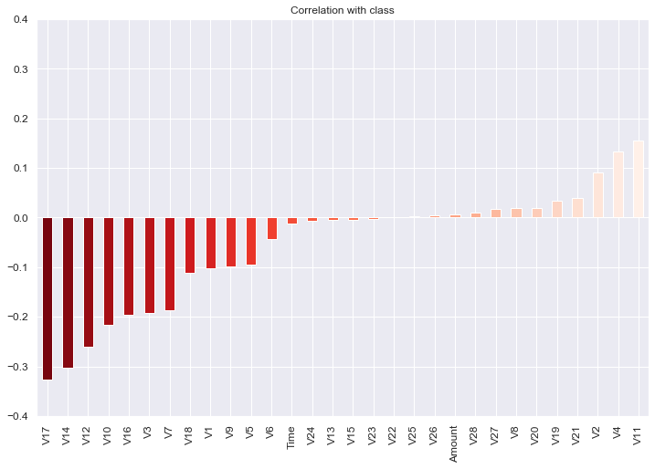

```python
target = 'Class'
df_corr = df.drop(target,1).corrwith(df[target]).sort_values()

df_corr.plot.bar(figsize = (12, 8), title = "Correlation with class",
          fontsize = 12,rot = 90, grid = True,
          color=sns.color_palette('Reds_r',30),ylim=(-0.4,0.4)
       )

# v17 14 12 and 10 has correlation more than 0.2
```

## Distribution plots

```python
df_corr.loc[ abs(df_corr.values)>0.2]
```

```
V17   -0.326481
V14   -0.302544
V12   -0.260593
V10   -0.216883
dtype: float64
```

```python
high_corr_idx = df_corr.loc[ abs(df_corr.values)>0.2].index.values.tolist()
high_corr_idx
```

```
['V17', 'V14', 'V12', 'V10']
```

```python
def dist_plot():
    for c in high_corr_idx:
        sns.distplot(df[c],fit=scipy.stats.norm)
        plt.xlim(-5,5)
        plt.show()
        plt.close()

# dist_plot()
```

```python
# clearly pdf is much different from gaussian distribution.
# to reduce skewness, we can we boxcox transform.
```

# Scaling

```python
# RobustScaler is less prone to outliers.
from sklearn.preprocessing import StandardScaler, RobustScaler

scaler = RobustScaler()

df['scaled_amount'] = scaler.fit_transform(df['Amount'].values.reshape(-1,1))
df['scaled_time'] = scaler.fit_transform(df['Time'].values.reshape(-1,1))
```

## Outliers Removal

[figure not shown]

```python
def boxplots_with_outliers():
    print('Before removing outliers from highest correlated features:')
    for c in high_corr_idx:
        plt.figure(figsize=(16,4))
        sns.boxplot(df[c])
        plt.show()
        plt.close()

# boxplots_with_outliers()
```

```python
# Find outliers using IQR method
q1 = df[high_corr_idx].quantile(0.25)
q3 = df[high_corr_idx].quantile(0.75)
iqr = q3 - q1
threshold = 1.5

cond1 = df[high_corr_idx] < (q1 - threshold * iqr)
cond2 = df[high_corr_idx] > (q3 + threshold * iqr)
cond = cond1 | cond2

idx_no_outliers = df[high_corr_idx][~(cond).any(axis=1)].index
idx_no_outliers[:5]
```

```
Int64Index([0, 1, 2, 3, 4], dtype='int64')
```

```python
df_no_outliers = df.loc[idx_no_outliers]
```

```python
df.shape, df_no_outliers.shape
```

```
((284807, 33), (250883, 33))
```

```python
def boxplots_no_outliers():
    print('After removing outliers from highest correlated features:')
    for c in high_corr_idx:
        plt.figure(figsize=(16,4))
        sns.boxplot(df_no_outliers[c])
        plt.show()
        plt.close()

# boxplots_no_outliers()
```

## StratifiedKFold splitting for imbalanced data

```python
from sklearn.model_selection import StratifiedKFold
```

```python
df.columns.values
```

```
array(['Time', 'V1', 'V2', 'V3', 'V4', 'V5', 'V6', 'V7', 'V8', 'V9',
       'V10', 'V11', 'V12', 'V13', 'V14', 'V15', 'V16', 'V17', 'V18',
       'V19', 'V20', 'V21', 'V22', 'V23', 'V24', 'V25', 'V26', 'V27',
       'V28', 'Amount', 'Class', 'scaled_amount', 'scaled_time'],
      dtype=object)
```

```python
target = 'Class'
features_no_log = df.columns.difference(['Amount','Time','Class']).values.tolist()
features_with_log = df.columns.difference(['scaled_amount','scaled_time','Class']).values.tolist()

idx = idx_no_outliers
cols = features_with_log

df_X = df.loc[idx,cols]
df_y = df.loc[idx,target]


skf = StratifiedKFold(n_splits=5, random_state=SEED, shuffle=True)

for idx_tr, idx_tx in skf.split(df_X, df_y):
    df_Xtrain, df_Xtest = df_X.iloc[idx_tr], df_X.iloc[idx_tx]
    df_ytrain, df_ytest = df_y.iloc[idx_tr], df_y.iloc[idx_tx]

# for imbalanced data, we use stratified k fold splitting
# class proportion are maintained same in train and test
df_ytrain.value_counts(normalize=True).append(df_ytest.value_counts(normalize=True))
```

```
0    0.999841
1    0.000159
0    0.999860
1    0.000140
Name: Class, dtype: float64
```

## Check for nans before modelling

```python
df.isnull().sum().sum()
```

```
0
```

```python
df['Class'].value_counts()
```

```
0    284315
1       492
Name: Class, dtype: int64
```

# Modelling LR with Imbalanced Data

```python
# we need numpy arrays for stratified splitting.
Xtrain = df_Xtrain.values
Xtest = df_Xtest.values
ytrain = df_ytrain.values
ytest = df_ytest.values
```

## Plain Logistic Regression

```python
from sklearn.linear_model import LogisticRegression
from sklearn.metrics import classification_report, recall_score

# define classifer
clf_lr = LogisticRegression(solver='liblinear',
                            max_iter=4000,
                            random_state=SEED,
                            n_jobs=1) # for liblinear n_jobs is +1.

# fit the classifier
clf_lr.fit(Xtrain,ytrain)

# get the prediction
ypreds_lr = clf_lr.predict(Xtest)

# model eval
recall = recall_score(ytest,ypreds_lr)
report = classification_report(ytest,ypreds_lr)

print(f'Recall Logistic Regression {recall: .2f}')
print(report)

# I got ZERO recall, all the frauds are classified as non-frauds
# the model overfitted since there are too many non-frauds cases.
```

```
Recall Logistic Regression  0.00
              precision    recall  f1-score   support

           0       1.00      1.00      1.00     50168
           1       0.00      0.00      0.00         7

    accuracy                           1.00     50175
   macro avg       0.50      0.50      0.50     50175
weighted avg       1.00      1.00      1.00     50175
```

```python
from bhishan.util_model_eval import get_binary_classification_scalar_metrics
```

```python
df_eval = get_binary_classification_scalar_metrics(
    "Logistic Regression",
    clf_lr,
    Xtest,ytest,
    ypreds_lr,
    desc="Train Test Imbalanced", df_eval=None)
```

|  | Model | Description | Accuracy | Precision | Recall | F1 | Mathews Correlation Coefficient | Cohens Kappa | Area Under Precision Curve | Area Under ROC Curve |
| --- | --- | --- | --- | --- | --- | --- | --- | --- | --- | --- |
| 0 | Logistic Regression | Train Test Imbalanced | 0.99986 | 0 | 0 | 0 | 0 | 0 | 0.00305379 | 0.624277 |

```python
from bhishan.util_model_eval import get_binary_classification_report
```

```python
df_clf_report = get_binary_classification_report("Logistic Regression",
  ytest,
  ypreds_lr,
  desc='',
  style_col='Recall_1',
  df_clf_report=None)
```

|  | Model | Description | Precision_0 | Precision_1 | Recall_0 | Recall_1 | F1_Score_0 | F1_Score_1 | Support_0 | Support_1 |
| --- | --- | --- | --- | --- | --- | --- | --- | --- | --- | --- |
| 0 | Logistic Regression |  | 0.99986 | 0 | 1 | 0 | 0.99993 | 0 | 50168 | 7 |

```python
print(classification_report(ytest, ypreds_lr))
```

```
              precision    recall  f1-score   support

           0       1.00      1.00      1.00     50168
           1       0.00      0.00      0.00         7

    accuracy                           1.00     50175
   macro avg       0.50      0.50      0.50     50175
weighted avg       1.00      1.00      1.00     50175
```

```python
from bhishan.util_model_eval import print_confusion_matrix_frauds
```

```python
print_confusion_matrix_frauds("Logistic Regression", ytest,ypreds_lr)
```

Logistic Regression

|  | Predicted_No_Fraud | Predicted_Fraud | Total_Frauds | Correct_Frauds | Incorrect_Frauds | Fraud_Detection |
| --- | --- | --- | --- | --- | --- | --- |
| No_Fraud | 50,168 | 0 | 7 | 0 | 7 | 0.00% |
| Fraud | 7 | 0 | 7 | 0 | 7 | 0.00% |

```python
confusion_matrix(ytest, ypreds_lr)
```

```
array([[50168,     0],
       [    7,     0]])
```

```python
from bhishan.util_model_eval import plot_confusion_matrix_plotly
```

```python
# plot_confusion_matrix_plotly(ytest, ypreds_lr)
```